# BIOS 611 Project 1

Alexander Quinter

07 October 2019

## Introduction

Urban Ministries is a non-profit organization that seeks to provide food, job opportunities, and other services to the homeless community of Durham and the surrounding area. Using the data provided by UM, I hope to provide meaningful insight into how the services they provide have changed over time, particularly with respect to the amount of food and school supplies the organization has provided to their clientele.

## Analyses

First, I decided to see if the amount of food and school supplies provided by the charity using two separate linear models. In both cases, I only used data starting from 1990, as this was the point when data started to be collected on a continuous basis. Additionally, I chose to run two separate models as the amount of times food was provided far exceeded the amount of times school supplies were provided, and to include them both in a single model would lead to the majority of food observations being dropped from the analysis, due to missing values for school supplies provided.

```r
#load in dataset
UMD.data=fread(file="C:/Users/alex/Documents/GitHub/bios611-projects-fall-2019-arquinter/project_1/data/UMD_Services_Provided_20190719.tsv")

#create analysis datasets
UMD.derived = UMD.data %>% mutate(ndate=as.Date(Date, "%m/%d/%Y")) %>% mutate(year=as.factor(format(as.Date(Date, "%m/%d/%Y"), "%Y")))
food.reg.df = na.omit(select(UMD.derived, ndate, year, `Food Pounds`)) %>%
  filter(!year %in% c("1931", "1941", "1951", "1961", "1971", "1981", "2021", "2022"), `Food Pounds` < 1000) %>% droplevels()
school.reg.df = na.omit(select(UMD.derived, ndate, year, `School Kits`)) %>%
  filter(!year %in% c("1931", "1941", "1951", "1961", "1971", "1981", "2021", "2022")) %>% droplevels()

#obtain results of statistical analyses
summary(lm(`Food Pounds`~ndate, data = food.reg.df))
```

```
##
## Call:
## lm(formula = `Food Pounds` ~ ndate, data = food.reg.df)
##
## Residuals:
##    Min     1Q Median     3Q    Max
## -25.83 -10.19  -2.50   8.22 481.58
##
## Coefficients:
##               Estimate Std. Error t value Pr(>|t|)
## (Intercept) -3.470e+01  7.034e-01  -49.34   <2e-16 ***
## ndate        3.346e-03  4.419e-05   75.70   <2e-16 ***
## ---
## Signif. codes:  0 '***' 0.001 '**' 0.01 '*' 0.05 '.' 0.1 ' ' 1
##
## Residual standard error: 15.8 on 67252 degrees of freedom
## Multiple R-squared:  0.07853,    Adjusted R-squared:  0.07851
## F-statistic:  5731 on 1 and 67252 DF,  p-value: < 2.2e-16
```

```r
summary(aov(`Food Pounds`~year, data = food.reg.df))
```

```
##                Df   Sum Sq Mean Sq F value Pr(>F)
## year           22  1579653   71802   290.3 <2e-16 ***
## Residuals   67231 16629329     247
## ---
## Signif. codes:  0 '***' 0.001 '**' 0.01 '*' 0.05 '.' 0.1 ' ' 1
```

```r
summary(lm(`School Kits`~ndate, data = school.reg.df))
```

```
##
## Call:
## lm(formula = `School Kits` ~ ndate, data = school.reg.df)
##
## Residuals:
##      Min       1Q   Median       3Q      Max
## -11.2251  -0.1390  -0.1268  -0.1045  16.4076
##
## Coefficients:
##               Estimate Std. Error t value Pr(>|t|)
## (Intercept) -2.402e+01  1.987e+00  -12.09   <2e-16 ***
## ndate        2.033e-03  1.574e-04   12.91   <2e-16 ***
## ---
## Signif. codes:  0 '***' 0.001 '**' 0.01 '*' 0.05 '.' 0.1 ' ' 1
##
## Residual standard error: 3.282 on 180 degrees of freedom
## Multiple R-squared:  0.4809, Adjusted R-squared:  0.478
## F-statistic: 166.8 on 1 and 180 DF,  p-value: < 2.2e-16
```

```r
summary(aov(`School Kits`~year, data = school.reg.df))
```

```
##              Df Sum Sq Mean Sq F value Pr(>F)
## year         14   2605  186.08    27.5 <2e-16 ***
## Residuals   167   1130    6.77
## ---
## Signif. codes:  0 '***' 0.001 '**' 0.01 '*' 0.05 '.' 0.1 ' ' 1
```

From the constructed ANOVA models, it was clear that the average amount of food and school supplies provided were not constant over time, but the significant value of the slope of the regression line pointed to a possible linear trend.

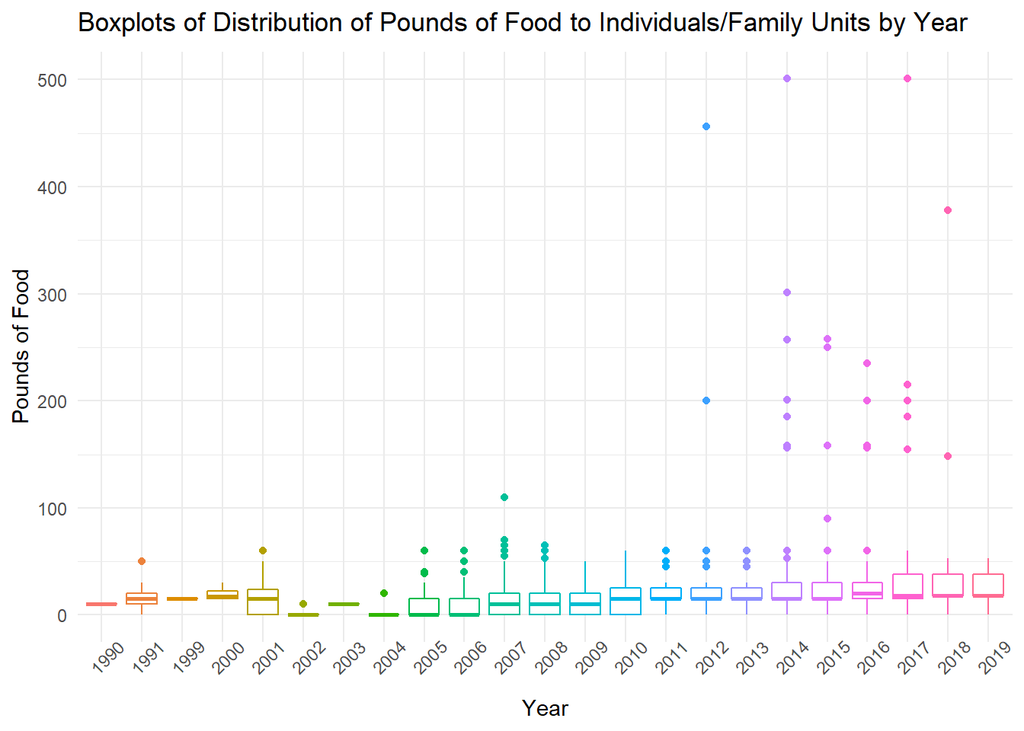

```r
#Create boxplots and models of relationship between Year and Pounds of Food Provided
ggplot(food.reg.df, aes(x=year, y=`Food Pounds`, color = year)) + geom_boxplot() + theme_minimal() + theme(axis.text.x =  element_text(angle = 45), legend.position = "none") +
  labs(x=expression('Year'), y=expression('Pounds of Food'),
  title=expression('Boxplots of Distribution of Pounds of Food to Individuals/Family Units by Year'))
```

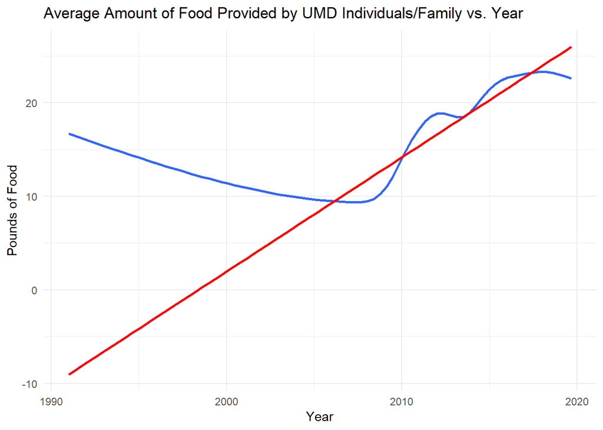

```r
ggplot(food.reg.df, aes(x=ndate, y=`Food Pounds`)) + geom_smooth(se=FALSE) + geom_smooth(method = "lm", se=FALSE, color='red') +
  theme_minimal() + labs(x=expression('Year'), y=expression('Pounds of Food'),
  title=expression('Average Amount of Food Provided by UMD Individuals/Family vs. Year'))
```

However, plotting a generalized additive model (GAM) to the food data indicated that the amount of food provided did not change constantly over time, but rather varied greatly. The advantage of plotting this GAM was that it makes the general trend of the data much clearer, though it is much less obvious how to interpret the exact relationship between pounds of food and year using the GAM. It did seem to be the case though that the amount of food provided increased over time, just not at a constant rate. I believe that the GAM is more preferable over the standard linear model, as while it is less interpretable, the lack of linearity in the data severely impairs the model’s usefulness.

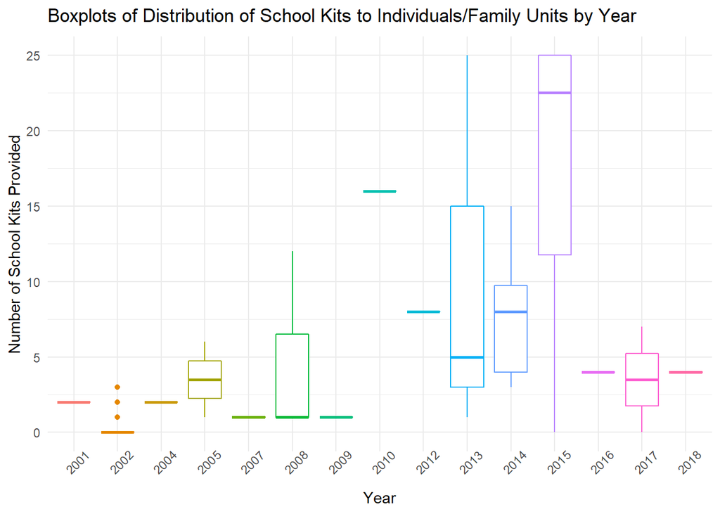

```r
#Create boxplots and models of relationship between Year and Number of School Kits Provided
ggplot(school.reg.df, aes(x=year, y=`School Kits`, color=year)) + geom_boxplot() + theme_minimal() + theme(axis.text.x =  element_text(angle = 45), legend.position = "none") +
  labs(x=expression('Year'), y=expression('Number of School Kits Provided'),
  title=expression('Boxplots of Distribution of School Kits to Individuals/Family Units by Year'))
```

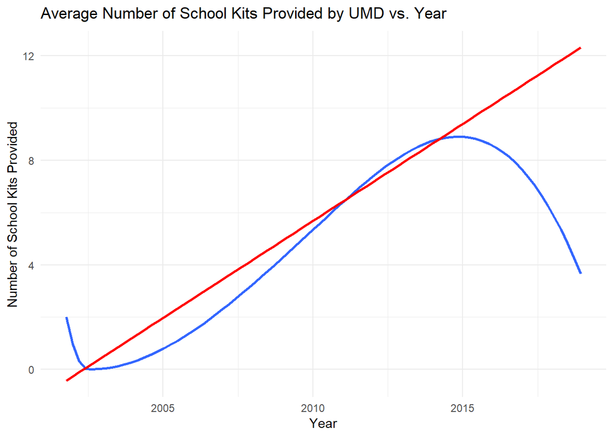

```r
ggplot(school.reg.df, aes(x=ndate, y=`School Kits`)) + geom_smooth(se=FALSE) + geom_smooth(method = "lm", se=FALSE, color='red') +
  theme_minimal() + labs(x=expression('Year'), y=expression('Number of School Kits Provided'),
  title=expression('Average Number of School Kits Provided by UMD vs. Year'))
```

## Conclusion

From the first set of graphs above, it can be seen that, while the average amount of food that UMD has been providing to its clients has increased over time, the amount of food provided varies greatly from year to year, making it hard to both pick out any general trends in the data and to predict the average amount of food UMD will need to provide to its clients in the future. One way UMD could try and lessen the variation in the data in order to obtain accurate estimates for future needs would be to record the number of individuals in each family unit when food is taken, and then average the amount of food taken by the number of individuals.  
The second set of graphs seems to indicate that, in general, the amount of school kits needed by individuals and family units has been increasing over the years, and thus UMD may want to consider increasing their stock of school supplies to meet this increasing demand. This conclusion is hampered, however by the apparent decrease in the number of school kits provided by UMD in the past several years, since around 2015. It is unclear whether this latest trend is due to some change in how UMD provides school kits to its clientele, or if it is due to some external change in some other aspect of the Durham community. From these results, I hope that UMD will be able to make more informed decisions on how they can better provide the necessary amount of food and school supplies needed by their clientele as a whole.